# hw10

Emily Dombrowski

2024-04-03

1. Using a for loop, write a function to calculate the number of zeroes in a numeric vector. Before entering the loop, set up a counter variable counter <- 0. Inside the loop, add 1 to counter each time you have a zero in the vector. Finally, use return(counter) for the output.

```r
counter <- 0 # setting up initial zero condition for counter
vec <- sample(x = c(0:1), size = 25, replace = TRUE)

for (i in 1:length(vec)) {
  if (vec[i] == 0)
  counter <- counter + 1
}

print(counter)
```

```
## [1] 10
```

2. Use subsetting instead of a loop to rewrite the function as a single line of code.

```r
length(vec[vec == 0])
```

```
## [1] 10
```

3. Write a function that takes as input two integers representing the number of rows and columns in a matrix. The output is a matrix of these dimensions in which each element is the product of the row number x the column number.

```r
matrix_frame <- function(numrow, numcol){
  m <- matrix(nrow = numrow, ncol = numcol)
   for (i in 1:numrow){
     for (j in 1:numcol){
      m[i,j] <- i * j
   }
   }
  return(m)
  }
matrix_frame(10,3)
```

```
##       [,1] [,2] [,3]
##  [1,]    1    2    3
##  [2,]    2    4    6
##  [3,]    3    6    9
##  [4,]    4    8   12
##  [5,]    5   10   15
##  [6,]    6   12   18
##  [7,]    7   14   21
##  [8,]    8   16   24
##  [9,]    9   18   27
## [10,]   10   20   30
```

4. Now let’s practice calling custom functions within a for loops. Use the code from previous lectures on loops and functions to complete the following steps:

-Simulate a dataset with 3 groups of data, each group drawn from a distribution with a different mean. The final data frame should have 1 column for group and 1 column for the response variable. -Write a custom function that 1) reshuffles the response variable, and 2) calculates the mean of each group in the reshuffled data. Store the means in a vector of length 3. -Use a for loop to repeat the function in b 100 times. Store the results in a data frame that has 1 column indicating the replicate number and 1 column for each new group mean, for a total of 4 columns. -Use qplot() to create a histogram of the means for each reshuffled group. Or, if you want a challenge, use ggplot() to overlay all 3 histograms in the same figure. How do the distributions of reshuffled means compare to the original means?

```r
var1 <- rnorm(10, 10)
var2 <- rnorm(10, 20)
var3 <- rnorm(10, 30)

df <- data.frame(group = c(rep("var1",10),
                      rep("var2",10),
                      rep("var3",10)),
                  response = c(var1, var2, var3))

shuffle <- function(dataframe){
  shuffle_df <- sample(dataframe$response)
  dataframe$shuffle <- shuffle_df
  aggregated <- aggregate(shuffle_df ~ group, dataframe, mean)
  return(aggregated)
}

shuffle_output <- shuffle(df)
mean_vec <- shuffle_output$shuffle_df
print(mean_vec)
```

```
## [1] 15.12310 23.55469 22.50050
```

```r
# make empty data frame for the results
results_df <- data.frame(replicate = numeric(0),
                         var1_mean = numeric(0),
                         var2_mean = numeric(0),
                         var3_mean = numeric(0))

for (i in 1:100){ # initialize 100 reps
  shuffle_result <- shuffle(df) # call function
  results_df <- rbind(results_df,# initialize calling empty df
                      c(i, shuffle_result[1,2],
                        shuffle_result[2,2],
                        shuffle_result[3,2]))
}

colnames(results_df) <- c("replicate", "var1_mean", "var2_mean", "var3_mean")

print(head(results_df))
```

```
##   replicate var1_mean var2_mean var3_mean
## 1         1  19.13800  22.39189  19.64840
## 2         2  19.85861  20.56237  20.75731
## 3         3  23.66540  17.51981  19.99308
## 4         4  22.44929  19.31618  19.41282
## 5         5  22.87547  18.82308  19.47974
## 6         6  20.38705  20.71678  20.07447
```

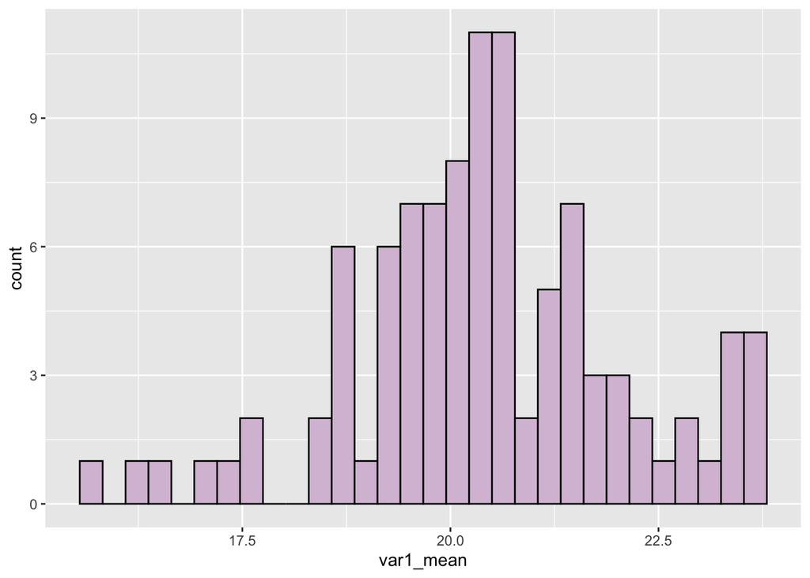

```r
p1 <- ggplot(data = results_df) +
  aes(x = var1_mean) +
  geom_histogram(fill = "thistle", color = "black")

p2 <- ggplot(data = results_df) +
  aes(x = var2_mean) +
  geom_histogram(fill = "goldenrod", color = "black")

p3 <- ggplot(data = results_df) +
  aes(x = var3_mean) +
  geom_histogram(fill = "thistle", color = "black")

print(p1)
```

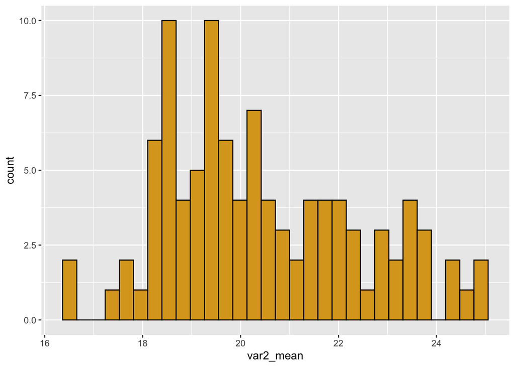

```r
print(p2)
```

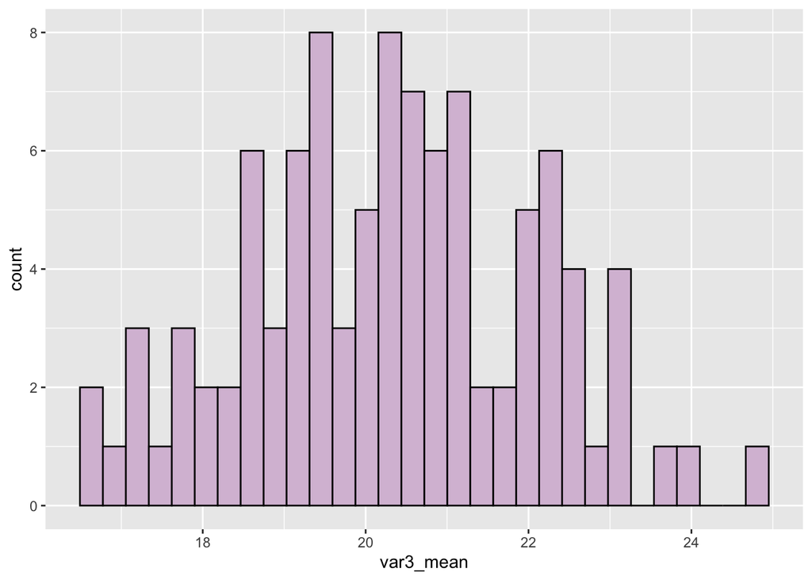

```r
print(p3)
```